# Predictive Model To Determine Weight Lift Quality

George F

August 19, 2015

### Executive Summary

Four models were developed to help predict the quality of exercises being performed. The accuracy of models when applied to the hold out test training set test validation (7846 rows and 160 columns) ranged from 95% to over 99%. Model 1, **Random Forest, Resampling: Cross-Validated (10 fold)**, resulted in 100% accuracy when applied to the 20 test cases. Models 2 & 3 also resulted in 100% accuracy. Model 4, Stochastic Gradient Boosting (gbm), Resampling: Cross-Validated (10 fold), resulted in 95% accuracy.

**Data-Preparation and Feature Selection**

[Training dataset](https://d396qusza40orc.cloudfront.net/predmachlearn/pml-training.csv) was partition into a 60% split (11776 rows and 160 columns) for model creation, and the remaining 40% was put asided for test validation (7846 rows and 160 columns). The final model will be applied to the 20 [Test dataset](https://d396qusza40orc.cloudfront.net/predmachlearn/pml-testing.csv) cases.

The final feature sets consisted of 39 response variables (e.g, pitch_belt, yaw_belt, total_accel_belt, gyros_belt_x, gyros_belt_y, gyros_belt_z). Summary of the variables removed:

- 100 summary statistics variables
- 7 metadata variables (user_name, raw_timestamp_part_1, …)
- 13 highly correlated variables

The training data consisted of a combination of response data from various sensors (gyros belt, magnet belt, gyros dumbbell, ..ect), and separate variables captured summary statistics at selected intervals (new_window == yes). 100 variables of the training set consisted of summary statistics. Out of 11776 rows in statistics were captured on 238 rows (i.e. new_window = yes) While the remaining observations were either null or NA. All statistic variables were removed from the model. Sample of the statistics removed included: min_yaw_dumbbell, kurtosis_picth_belt, stddev_pitch_forearm, stddev_yaw_forearm, kurtosis_picth_dumbbell, stddev_pitch_belt, var_yaw_arm, avg_pitch_belt, avg_roll_forearm, max_roll_dumbbell

After removing the metadata variables (X, user_name, raw_timestamp_part_1, raw_timestamp_part_2, cvtd_timestamp, new_window, num_window) the findCorrelation highlighted 13 highly correlated variables. These parameters were dropped (accel_belt_z, roll_belt, accel_belt_y, accel_dumbbell_z, accel_belt_x, magnet_belt_x, accel_dumbbell_x, accel_arm_x, magnet_arm_y, gyros_forearm_y, gyros_dumbbell_x, gyros_dumbbell_z, gyros_arm_x)

**Model Choices and Analysis**

Based on the authors input in their paper [Qualitative Activity Recognition of Weight Lifting Exercises](http://groupware.les.inf.puc-rio.br/public/papers/2013.Velloso.QAR-WLE.pdf), I decided to run three random forest models with 2 different cross-validations and 1 out-of-bag. In addition Stochastic Gradient Boosting (gbm) with 10 fold cross-validation.

```
    * Random Forest, Resampling: Cross-Validated (10 fold)
    * Random Forest, trainControl(method="oob")
    * Random Forest, Resampling: Cross-Validated (2 fold)
    * Stochastic Gradient Boosting (gbm), Resampling: Cross-Validated (10 fold)
```

In order to estimate the out of sample accuracy I applied the predict function for each model to help estimate the out of sample error on the test set ((7846 rows and 153 columns)). Summary results for each model are listed below, and Figure 1 below includes Accuracy plot for model 1.

*Model 1: Random Forest, Resampling: Cross-Validated (10 fold)* Overall Statistics

```
           Accuracy : 0.9929
             95% CI : (0.9907, 0.9946)
No Information Rate : 0.2852
P-Value [Acc > NIR] : < 2.2e-16

              Kappa : 0.991
```

*Model 2: Random Forest, trainControl(method=“oob”)*

Overall Statistics

```
           Accuracy : 0.9897
             95% CI : (0.9872, 0.9918)
No Information Rate : 0.286
P-Value [Acc > NIR] : < 2.2e-16

              Kappa : 0.9869
```

*Model 3: Random Forest, Resampling: Cross-Validated (2 fold)*

Overall Statistics

```
           Accuracy : 0.9922
             95% CI : (0.99, 0.994)
No Information Rate : 0.2859
P-Value [Acc > NIR] : < 2.2e-16

              Kappa : 0.9902
```

*Model 4: Stochastic Gradient Boosting (gbm), Resampling: Cross-Validated (10 fold)*

Overall Statistics

```
           Accuracy : 0.9528
             95% CI : (0.9479, 0.9574)
No Information Rate : 0.2882
P-Value [Acc > NIR] : < 2.2e-16

              Kappa : 0.9403
```

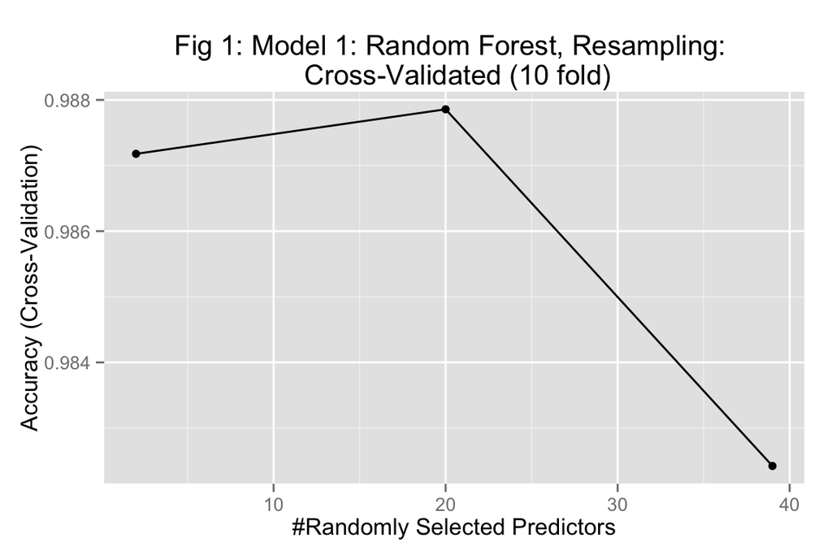